# RaMP-DB 2.0 Vignette

Kyle Spencer, Ewy Mathé, Andrew Patt, and Cole Tindall

2022-03-18

## Introduction

This vignette will provide basic steps for interacting with [RaMP-DB](https://www.ncbi.nlm.nih.gov/pmc/articles/PMC5876005/) (Relational database of Metabolomic Pathways).  
The codebase for RaMP-DB is available on [our GitHub site](https://github.com/ncats/RaMP-DB). Details on RaMP-DB installation are also avaialble through GitHub, and questions can be asked through the Issues tab or by sending an email to NCATSRaMP@nih.gov.

RaMP-DB supports queries and enrichment analyses. Supported queries are:

- Retrieve Analytes From Input Pathway(s)
- Retrieve Pathways From Input Analyte(s)
- Retrieve Metabolites from Metabolite Ontologies
- Retrieve Ontologies from Input Metabolites
- Retrieve Analytes Involved in the Same Reaction
- Retrieve Chemical Classes from Input Metabolites
- Retrieve Chemical Properties from Input Metabolites

Supported enrichment analyses are:

- Perform Pathway Enrichment
- Perform Chemical Enrichment

Once installed, first load the package:

```r
library(RaMP)
library(DT) # for prettier tables in vignette
library(dplyr)
library(magrittr)
pkg.globals <- setConnectionToRaMP(
  dbname = "ramp", username = "root", conpass = "",
  host = "localhost")
```

The latter line cannot be modified, other than changes to the parameters inside the function (e.g., values for dbname, username, conpass, and host). For example, if your password is different than ““, you would set conpass=”mypassword”. This line needs be run only once, every time the package is loaded.

## Supported RaMP Queries

### Retrieve Analytes From Input Pathway(s)

Analytes (genes, proteins, metabolites) can be retrieve by pathway. Users have to input the exact pathway name. Here is an example:

```r
myanalytes <- getAnalyteFromPathway(pathway="sphingolipid metabolism")
```

```
## [1] "fired"
## [1] "Timing .."
##    user  system elapsed
##   0.617   0.033   0.739
```

```r
datatable(myanalytes)
```

|  | pathwayName | pathwayType | analyteName | sourceAnalyteIDs | geneOrCompound |
| --- | --- | --- | --- | --- | --- |
| 1 | Sphingolipid metabolism | kegg |  | gene_symbol:(REFSEQ) EXTRACELL; uniprot:Q4WQS0; hmdb:HMDBP14218 | gene |
| 2 | Sphingolipid metabolism | kegg | NEU1 | uniprot:Q99519; entrez:4758; gene_symbol:NEU1; ensembl:ENSG00000204386; uniprot:Q5JQI0; uniprot:E9PI... | gene |
| 3 | Sphingolipid metabolism | reactome | Glc | chebi:17925; hmdb:HMDB0003345; kegg:C00267; pubchem:79025; chemspider:71358; CAS:492-62-6; wikidata:... | compound |
| 4 | Sphingolipid metabolism | reactome | Palmitaldehyde | hmdb:HMDB0001551; chebi:17600; chemspider:959; kegg:C00517; pubchem:984; CAS:629-80-1; wikidata:Q270... | compound |
| 5 | Sphingolipid metabolism | reactome | UDP-D-galactose | chebi:18307; pubchem:18068; CAS:2956-16-3; chemspider:5256749; pubchem:6857410; hmdb:HMDB0000302; wi... | compound |
| 6 | Sphingolipid metabolism | reactome | Hydrogen sulfide | hmdb:HMDB0003276; pubchem:402; chemspider:391; kegg:C00283; chebi:16136; CAS:7783-06-4; wikidata:Q17... | compound |
| 7 | Sphingolipid metabolism | reactome | Sphing-4-enine-1-phosphate | pubchem:5283560; chebi:37550; LIPIDMAPS:LMSP01050001; hmdb:HMDB0000277; kegg:C06124; wikidata:Q41826... | compound |
| 8 | Sphingolipid metabolism | reactome | Stearoyl-CoA | kegg:C00412; pubchem:94140; CAS:362-66-3; LIPIDMAPS:LMFA07050369; chebi:15541; hmdb:HMDB0001114; che... | compound |
| 9 | Sphingolipid metabolism | reactome | PE(P-18:0/20:4(5Z,8Z,11Z,14Z)) | pubchem:53479607; chemspider:24768618; chemspider:24768814; chemspider:24768469; pubchem:53479603; c... | compound |
| 10 | Sphingolipid metabolism | reactome | DG(18:1(9Z)/20:1(11Z)/0:0) | hmdb:HMDB0007224; hmdb:HMDB0007257; hmdb:HMDB0007398; chebi:82929; hmdb:HMDB0007248; chemspider:7822... | compound |

[output cut: 312 more lines]

To retrieve information from multiple pathways, input a vector of pathway names:

```r
myanalytes <- getAnalyteFromPathway(pathway=c("De Novo Triacylglycerol Biosynthesis",
                                              "sphingolipid metabolism"))
```

```
## [1] "fired"
## [1] "Timing .."
##    user  system elapsed
##   0.193   0.005   0.314
```

### Retrieve Pathways From Input Analyte(s)

It is oftentimes useful to get a sense of what pathways are represented in a dataset (this is particularly true for metabolomics, where coverage of metabolites varies depending on what platform is used). In other cases, one may be interested in exploring one or several metabolites to see what pathways they are arepresented in.

Note that it is always preferable to utilize IDs rather then common names. When entering IDs, prepend each ID with the database of origin followed by a colon, for example kegg:C02712, hmdb:HMDB04824, etc.. It is possible to input IDs using multiple different sources. RaMP currently supports the following ID types (that should be prepended):

```r
  metabprefixes <- getPrefixesFromAnalytes("metabolite")
  geneprefixes <- getPrefixesFromAnalytes("gene")

  datatable(rbind(metabprefixes, geneprefixes))
```

|  | analyteType | idTypes |
| --- | --- | --- |
| 1 | Metabolites | LIPIDMAPS, pubchem, hmdb, chemspider, chebi, CAS, wikidata, swisslipids, kegg, lipidbank, plantfa, kegg_glycan |
| 2 | Genes/Proteins | uniprot, hmdb, gene_symbol, entrez, ensembl, ncbiprotein, EN, wikidata, chebi |

```r
pathwaydfids <- getPathwayFromAnalyte(c("ensembl:ENSG00000135679", "hmdb:HMDB0000064",
        "hmdb:HMDB0000148", "ensembl:ENSG00000141510"))
```

```
## [1] "Starting getPathwayFromAnalyte()"
## [1] "Working on ID List..."
## [1] "finished getPathwaytFromAnalyte()"
## [1] "Found 316 associated pathways."
```

```r
datatable(pathwaydfids)
```

|  | pathwayName | pathwaySource | pathwayId | inputId | commonName |
| --- | --- | --- | --- | --- | --- |
| 1 | 16p11.2 proximal deletion syndrome | wiki | WP4949 | ensembl:ENSG00000141510 | TP53 |
| 2 | 22q11.2 copy number variation syndrome | wiki | WP4657 | ensembl:ENSG00000141510 | TP53 |
| 3 | Activation of BH3-only proteins | reactome | R-HSA-114452 | ensembl:ENSG00000141510 | TP53 |
| 4 | Activation of NOXA and translocation to mitochondria | reactome | R-HSA-111448 | ensembl:ENSG00000141510 | TP53 |
| 5 | Activation of PUMA and translocation to mitochondria | reactome | R-HSA-139915 | ensembl:ENSG00000141510 | TP53 |
| 6 | AKT phosphorylates targets in the cytosol | reactome | R-HSA-198323 | ensembl:ENSG00000135679 | MDM2 |
| 7 | Alanine, aspartate and glutamate metabolism | kegg | map00250 | hmdb:HMDB0000148 | Glutamate; L-Glutamic acid |
| 8 | Amino acid metabolism | wiki | WP3925 | hmdb:HMDB0000148 | Glutamate; L-Glutamic acid |
| 9 | Amino acid metabolism pathway excerpt: histidine catabolism extension | wiki | WP4661 | hmdb:HMDB0000148 | Glutamate; L-Glutamic acid |
| 10 | Amino Sugar Metabolism | kegg | map00520 | hmdb:HMDB0000148 | Glutamate; L-Glutamic acid |

[output cut: 306 more lines]

Note that each row returns a pathway attributed to one of the input analytes. To retrieve the number of unique pathways returned for all analytes or each analyte, try the following:

```r
print(paste("Number of Unique Pathways Returned for All Analytes:",
            length(unique(pathwaydfids$pathwayId))))
```

```
## [1] "Number of Unique Pathways Returned for All Analytes: 247"
```

```r
lapply(unique(pathwaydfids$commonName), function(x) {
        (paste("Number of Unique Pathways Returned for",x,":",
                length(unique(pathwaydfids[which(pathwaydfids$commonName==x),]$pathwayId))))})
```

```
## [[1]]
## [1] "Number of Unique Pathways Returned for TP53 : 185"
##
## [[2]]
## [1] "Number of Unique Pathways Returned for MDM2 : 83"
##
## [[3]]
## [1] "Number of Unique Pathways Returned for Glutamate; L-Glutamic acid : 39"
##
## [[4]]
## [1] "Number of Unique Pathways Returned for Creatine : 9"
```

### Retrieve Metabolites from Metabolite Ontologies

Conversely, the user can retrieve the metabolites that are associated with a specific ontology or vector of ontologies. We can accomplish this using the function getMetaFromOnto(). It should be noted that it does not matter which ontology the metabolites are from. The function will return all metabolites associated with all the ontologies specified by the user.

```r
ontologies.of.interest <- c("Colon", "Liver", "Lung")

new.metabolites <- RaMP::getMetaFromOnto(ontology = ontologies.of.interest)
```

```
## [1] "Retreiving Metabolites for input ontology terms."
## [1] "Found 3 ontology term matches."
## [1] "Found 1529 metabolites associated with the input ontology terms."
## [1] "Finished getting metabolies from ontology terms."
```

```r
datatable(new.metabolites)
```

|  | ontologyTerm | ontologyCategory | metNames | metIds |
| --- | --- | --- | --- | --- |
| 1 | Colon | Organ and components | Methanethiol | CAS:74-93-1; chebi:16007; chemspider:855; hmdb:HMDB0003227; kegg:C00409; pubchem:878 |
| 2 | Colon | Organ and components | H2S; Hydrogen sulfide | CAS:7783-06-4; chebi:16136; chemspider:391; hmdb:HMDB0003276; kegg:C00283; pubchem:402; wikidata:Q170591 |
| 3 | Liver | Organ and components | 4-Pyridoxic acid; PDXate | CAS:82-82-6; chebi:17405; chemspider:6467; hmdb:HMDB0000017; kegg:C00847; pubchem:6723; wikidata:Q27102382 |
| 4 | Liver | Organ and components | 7-dehdrocholesterol; 7-dehydroCHOL; 7-Dehydrocholesterol; cholesta-5,7-dien-3beta-ol | CAS:434-16-2; chebi:17759; chemspider:388534; hmdb:HMDB0000032; kegg:C01164; lipidbank:VVD0245; LIPIDMAPS:LMST01010069; pubchem:439423; swisslipids:SLM:000000042; wikidata:Q139350 |
| 5 | Liver | Organ and components | CARN; Carnosine | CAS:305-84-0; chebi:15727; chemspider:388363; hmdb:HMDB0000033; kegg:C00386; pubchem:439224; wikidata:Q413822 |
| 6 | Liver | Organ and components | N-(3alpha,7alpha,12alpha-trihydroxy-5beta-cholan-24-oyl)-taurine; Taurocholic acid; TCCA | CAS:81-24-3; chebi:181348; chebi:28865; chemspider:23977248; chemspider:6423; hmdb:HMDB0000036; kegg:C05122; LIPIDMAPS:LMST05040001; pubchem:6675; swisslipids:SLM:000485655; wikidata:Q2659931 |
| 7 | Liver | Organ and components | Acetate; Acetic acid; CH3COO-; ethanoic acid | CAS:64-19-7; chebi:15366; chemspider:171; hmdb:HMDB0000042; kegg:C00033; lipidbank:DFA0002; LIPIDMAPS:LMFA01010002; plantfa:10010; pubchem:176; swisslipids:SLM:000000449; wikidata:Q47512 |
| 8 | Liver | Organ and components | BET; Betaine; glycine betaine | CAS:107-43-7; CAS:6915-17-9; chebi:17750; chebi:41139; chemspider:242; chemspider:243; hmdb:HMDB0000043; kegg:C00719; pubchem:247; pubchem:248; wikidata:Q10860583 |
| 9 | Liver | Organ and components | Ascorbic acid; L-ascorbic acid | CAS:50-81-7; chebi:29073; chemspider:10189562; hmdb:HMDB0000044; kegg:C01041; pubchem:54670067; wikidata:Q199678 |
| 10 | Liver | Organ and components | androst-4-ene-3,17-dione; Androstenedione | CAS:63-05-8; chebi:16422; chemspider:5898; hmdb:HMDB0000053; kegg:C00280; lipidbank:SST0028; LIPIDMAPS:LMST02020007; pubchem:6128; swisslipids:SLM:000001060; wikidata:Q411064 |

[output cut: 1519 more lines]

### Retrieve Ontologies from Input Metabolites

To retrieve ontologies that are associated with our metabolites we can use getOntoFromMeta(). This function takes in a vector of metabolites as an input and returns a vector comprised of the ontologies from the user’s defined metabolites.

```r
analytes.of.interest <- c("ensembl:ENSG00000135679", "hmdb:HMDB0000064",
        "hmdb:HMDB0000148", "ensembl:ENSG00000141510")
new.ontologies <- RaMP::getOntoFromMeta(analytes = analytes.of.interest)
datatable(new.ontologies)
```

|  | Metabolites | sourceId | IDtype | Ontology | HMDBOntologyType |
| --- | --- | --- | --- | --- | --- |
| 1 | Creatine | hmdb:HMDB0000064 | hmdb | Saliva | Biofluid and excreta |
| 3 | Creatine | hmdb:HMDB0000064 | hmdb | Plant | Source |
| 5 | Creatine | hmdb:HMDB0000064 | hmdb | Food | Source |
| 7 | Creatine | hmdb:HMDB0000064 | hmdb | Feces | Biofluid and excreta |
| 9 | Creatine | hmdb:HMDB0000064 | hmdb | Urine | Biofluid and excreta |
| 11 | Creatine | hmdb:HMDB0000064 | hmdb | Cerebrospinal fluid | Biofluid and excreta |
| 13 | Creatine | hmdb:HMDB0000064 | hmdb | Animal | Source |
| 15 | Creatine | hmdb:HMDB0000064 | hmdb | Blood | Biofluid and excreta |
| 17 | Creatine | hmdb:HMDB0000064 | hmdb | Synthetic | Source |
| 19 | Creatine | hmdb:HMDB0000064 | hmdb | Endogenous | Source |

[output cut: 103 more lines]

### Retrieve Analytes Involved in the Same Reaction

The user may want to know what gene transcripts encode enzymes which can catalyze reactions involving metabolites in their experiment. RaMP can return this data to its user.

We can return the gene transcripts using the rampFastCata() function. To use it the user needs to provide a vector of metabolites they are interested in and the connection information for MySQL. The user can also input a vector of protein IDs or gene transcripts to return the metabolites involved in chemical reactions with the input proteins or gene transcript encoded proteins.

```r
#Input Metabolites
analytes.of.interest <- c("ensembl:ENSG00000135679", "hmdb:HMDB0000064",
        "hmdb:HMDB0000148", "ensembl:ENSG00000141510")

new.transcripts <- rampFastCata(analytes = analytes.of.interest)
```

```
## [1] "Analyte ID-based reaction partner query."
## [1] "Building metabolite to gene relations."
## [1] "Number of met2gene relations: 100"
## [1] "Building gene to metabolite relations."
## [1] "Total Relation Count: 104"
```

```r
datatable(new.transcripts)
```

|  | query_relation | input_analyte | input_common_names | rxn_partner_common_name | rxn_partner_ids |
| --- | --- | --- | --- | --- | --- |
| 1 | met2gene | hmdb:HMDB0000148 | Glutamate; L-Glutamic acid | BCAT1 | ensembl:ENSG00000060982; entrez:586; gene_symbol:BCAT1; hmdb:HMDBP00301; uniprot:A0A024RAV0; uniprot:A0A087WYF2; uniprot:F5H2F2; uniprot:P54687 |
| 2 | met2gene | hmdb:HMDB0000148 | Glutamate; L-Glutamic acid | BCAT2 | ensembl:ENSG00000105552; entrez:587; gene_symbol:BCAT2; hmdb:HMDBP00516; uniprot:B3KSI3; uniprot:M0QXF9; uniprot:M0QZ10; uniprot:M0QZP4; uniprot:M0R2K7; uniprot:O15382 |
| 3 | met2gene | hmdb:HMDB0000148 | Glutamate; L-Glutamic acid | SLC16A1 | ensembl:ENSG00000155380; entrez:6566; gene_symbol:SLC16A1; hmdb:HMDBP01111; uniprot:A0A024R0H1; uniprot:P53985; uniprot:Q5T8R3; uniprot:Q5T8R4; uniprot:Q5T8R5 |
| 4 | met2gene | hmdb:HMDB0000148 | Glutamate; L-Glutamic acid | EPRS; EPRS1 | ensembl:ENSG00000136628; entrez:2058; gene_symbol:EPRS; gene_symbol:EPRS1; hmdb:HMDBP00567; uniprot:P07814; uniprot:V9GYZ6; uniprot:V9GZ76 |
| 5 | met2gene | hmdb:HMDB0000148 | Glutamate; L-Glutamic acid | ASNS | ensembl:ENSG00000070669; entrez:440; gene_symbol:ASNS; hmdb:HMDBP00583; uniprot:C9J057; uniprot:C9J605; uniprot:C9JLA3; uniprot:C9JLN6; uniprot:C9JM09; uniprot:C9JT45; uniprot:F8WEJ5; uniprot:P08243 |
| 6 | met2gene | hmdb:HMDB0000148 | Glutamate; L-Glutamic acid | GMPS | ensembl:ENSG00000163655; entrez:8833; gene_symbol:GMPS; hmdb:HMDBP00592; uniprot:A0A140VJK6; uniprot:P49915 |
| 7 | met2gene | hmdb:HMDB0000148 | Glutamate; L-Glutamic acid | NADSYN1 | ensembl:ENSG00000172890; entrez:55191; gene_symbol:NADSYN1; hmdb:HMDBP03241; uniprot:A0A0B4J216; uniprot:E9PKY6; uniprot:E9PND0; uniprot:E9PNF5; uniprot:H0YCF9; uniprot:H0YCQ6; uniprot:H0YDH3; uniprot… |
| 8 | met2gene | hmdb:HMDB0000148 | Glutamate; L-Glutamic acid | EARS2 | ensembl:ENSG00000103356; entrez:124454; gene_symbol:EARS2; hmdb:HMDBP07382; uniprot:H3BPY3; uniprot:H3BQI0; uniprot:H3BQP8; uniprot:H3BTB7; uniprot:I3L166; uniprot:Q5JPH6 |
| 9 | met2gene | hmdb:HMDB0000148 | Glutamate; L-Glutamic acid | CCBL1; KYAT1 | ensembl:ENSG00000171097; entrez:883; gene_symbol:CCBL1; gene_symbol:KYAT1; hmdb:HMDBP00464; uniprot:A8K563; uniprot:B7Z4W5; uniprot:Q16773; uniprot:Q5T276; uniprot:Q5T277; uniprot:Q5T278 |
| 10 | met2gene | hmdb:HMDB0000148 | Glutamate; L-Glutamic acid | GLUD2 | ensembl:ENSG00000182890; entrez:2747; gene_symbol:GLUD2; hmdb:HMDBP00666; uniprot:A0A140VK14; uniprot:P49448 |

[output cut: 94 more lines]

```r
#Input Proteins
proteins.of.interest <- c("uniprot:094808", "uniprot:Q99259")

new.metabolites <- rampFastCata(analytes = proteins.of.interest)
```

```
## [1] "Analyte ID-based reaction partner query."
## [1] "Building metabolite to gene relations."
## [1] "Number of met2gene relations: 0"
## [1] "Building gene to metabolite relations."
## [1] "Total Relation Count: 12"
```

```r
datatable(new.metabolites)
```

|  | query_relation | input_analyte | input_common_names | rxn_partner_common_name | rxn_partner_ids |
| --- | --- | --- | --- | --- | --- |
| 1 | gene2met | uniprot:Q99259 | GAD1 | b-Ala; beta-Alanine | CAS:107-95-9; chebi:16958; chemspider:234; hmdb:HMDB0000056; kegg:C00099; pubchem:239; wikidata:Q310919 |
| 2 | gene2met | uniprot:Q99259 | GAD1 | 4-amino-butanoic acid; 4-Aminobutanoic acid; GABA; gamma-Aminobutyric acid; γ-aminobutyric acid | CAS:56-12-2; chebi:16865; chemspider:116; hmdb:HMDB0000112; kegg:C00334; LIPIDMAPS:LMFA01100039; pubchem:119; wikidata:Q210021 |
| 3 | gene2met | uniprot:Q99259 | GAD1 | Glutamate; Glutamic acid; L-Glutamate; L-Glutamic acid | CAS:56-86-0; chebi:16015; chemspider:30572; hmdb:HMDB0000148; kegg:C00025; pubchem:33032; wikidata:Q26995161 |
| 4 | gene2met | uniprot:Q99259 | GAD1 | Asp; Aspartate; L-Aspartic acid | CAS:56-84-8; chebi:17053; chemspider:5745; hmdb:HMDB0000191; kegg:C00049; pubchem:5960; wikidata:Q178450 |
| 5 | gene2met | uniprot:Q99259 | GAD1 | TAU; Taurine | CAS:107-35-7; chebi:15891; chemspider:1091; hmdb:HMDB0000251; kegg:C00245; pubchem:1123; wikidata:Q207051 |
| 6 | gene2met | uniprot:Q99259 | GAD1 | N-Carbamoyl-L-aspartate; Ureidosuccinic acid | CAS:13184-27-5; chebi:15859; chemspider:84022; hmdb:HMDB0000828; kegg:C00438; pubchem:93072; wikidata:Q2823324; wikidata:Q55177068 |
| 7 | gene2met | uniprot:Q99259 | GAD1 | Hypotaurine | CAS:300-84-5; chebi:16668; chemspider:96959; hmdb:HMDB0000965; kegg:C00519; pubchem:107812; wikidata:Q3138539 |
| 8 | gene2met | uniprot:Q99259 | GAD1 | 3-sulfino-L-alanine; 3-Sulfinoalanine; CSA | CAS:1115-65-7; chebi:16345; chemspider:1266065; hmdb:HMDB0000996; kegg:C00606; pubchem:1549098; wikidata:Q2823252 |
| 9 | gene2met | uniprot:Q99259 | GAD1 | PXLP; Pyridoxal 5'-phosphate | CAS:54-47-7; chebi:18405; chemspider:1022; hmdb:HMDB0001491; kegg:C00018; pubchem:1051; wikidata:Q418957 |
| 10 | gene2met | uniprot:Q99259 | GAD1 | Famotidine | CAS:76824-35-6; chebi:4975; chemspider:3208; hmdb:HMDB0001919; pubchem:3325 |

[output cut: 2 more lines]

RaMP has a built in function which is able to generate networks from the transcript data. This function is named plotCataNetwork(). This function uses the dataframe created by rampFastCata() as an input. These plots are completely interactive.

```r
plotCataNetwork(new.transcripts)
```

[interactive chart not shown]

### Retrieve Chemical Classes from Input Metabolites

RaMP incorporates Classfire and lipidMAPS classes. The function chemicalClassSurvey() function takes as input a vector of metabolites and outputs the classes associated with each metabolite input.

```r
metabolites.of.interest = c('hmdb:HMDB0000056','hmdb:HMDB0000439','hmdb:HMDB0000479','hmdb:HMDB0000532',
                            'hmdb:HMDB0001015','hmdb:HMDB0001138','hmdb:HMDB0029159','hmdb:HMDB0029412',
                            'hmdb:HMDB0034365','hmdb:HMDB0035227','hmdb:HMDB0007973','hmdb:HMDB0008057',
                            'hmdb:HMDB0011211')
chemical.classes <- chemicalClassSurvey(mets = metabolites.of.interest)
```

```
## [1] "Starting Chemical Class Survey"
## [1] "...finished metabolite list query..."
## [1] "...finished DB population query..."
## [1] "...colating data..."
## [1] "...creating query efficiency summary..."
## [1] "Finished Chemical Class Survey"
```

```r
metabolite.classes <- as.data.frame(chemical.classes$met_classes)
datatable(metabolite.classes)
```

|  | sourceId | common_names | class_level_name | class_name | source |
| --- | --- | --- | --- | --- | --- |
| 1 | hmdb:HMDB0000479 | 3-Methylhistidine | ClassyFire_class | Carboxylic acids and derivatives | hmdb |
| 2 | hmdb:HMDB0000479 | 3-Methylhistidine | ClassyFire_sub_class | Amino acids, peptides, and analogues | hmdb |
| 3 | hmdb:HMDB0000479 | 3-Methylhistidine | ClassyFire_super_class | Organic acids and derivatives | hmdb |
| 4 | hmdb:HMDB0000056 | beta-Alanine | ClassyFire_class | Carboxylic acids and derivatives | hmdb |
| 5 | hmdb:HMDB0000056 | beta-Alanine | ClassyFire_sub_class | Amino acids, peptides, and analogues | hmdb |
| 6 | hmdb:HMDB0000056 | beta-Alanine | ClassyFire_super_class | Organic acids and derivatives | hmdb |
| 7 | hmdb:HMDB0000439 | 2-Furoylglycine | ClassyFire_class | Carboxylic acids and derivatives | hmdb |
| 8 | hmdb:HMDB0000439 | 2-Furoylglycine | ClassyFire_sub_class | Amino acids, peptides, and analogues | hmdb |
| 9 | hmdb:HMDB0000439 | 2-Furoylglycine | ClassyFire_super_class | Organic acids and derivatives | hmdb |
| 10 | hmdb:HMDB0000532 | Acetylglycine | ClassyFire_class | Carboxylic acids and derivatives | hmdb |

[output cut: 38 more lines]

### Retrieve Chemical Property Information from Input Metabolites

Chemical properties captured by RaMP include SMILES, InChI, InChI-keys, monoisotopic masses, molecular formula, and common name. The getChemicalProperties() function takes as input a vector of metabolites and outputs a list of chemical property information that can easily be converted into a dataframe.

```r
chemical.properties <- getChemicalProperties(metabolites.of.interest)
```

```
## Starting Chemical Property Query
```

```
## Finished Chemical Property Query
```

```r
chemical.data <- chemical.properties$chem_props
datatable(chemical.data)
```

|  | chem_data_source | chem_source_id | iso_smiles | inchi_key_prefix | inchi_key | inchi | mw | monoisotop_mass | common_name | mol_formula |
| --- | --- | --- | --- | --- | --- | --- | --- | --- | --- | --- |
| 1 | hmdb | hmdb:HMDB0029412 | C[N+]1(C)C[C@H](O)C[C@H]1C([O-])=O | MUNWAHDYFVYIKH | MUNWAHDYFVYIKH-RITPCOANSA-N | InChI=1S/C7H13NO3/c1-8(2)4-5(9)3-6(8)7(10)11/h5-6,9H,3-4H2,1-2H3/t5-,6+/m1/s1 | 159.182998657227 | 159.089996337891 | Betonicine | C7H13NO3 |
| 2 | hmdb | hmdb:HMDB0000056 | NCCC(O)=O | UCMIRNVEIXFBKS | UCMIRNVEIXFBKS-UHFFFAOYSA-N | InChI=1S/C3H7NO2/c4-2-1-3(5)6/h1-2,4H2,(H,5,6) | 89.0932006835938 | 89.0476989746094 | beta-Alanine | C3H7NO2 |
| 3 | hmdb | hmdb:HMDB0011211 | CCCCCCCCCCCCCC\C=C/OC[C@]([H])(COP([O-])(=O)OCC[N+](C)(C)C)OC(=O)CCCCCCC\C=C/C\C=C/CCCCC | QLEHHUPUHJPURI | QLEHHUPUHJPURI-PWYDUFMYSA-N | InChI=1S/C42H80NO7P/c1-6-8-10-12-14-16-18-20-22-23-25-27-29-31-33-35-42(44)50-41(40-49-51(45,46)48-38-36-43(3,4)5)39-47-37-34-32-30-28-26-24-21-19-17-15-13-11-9-7-2/h14,16,20,22,34,37,41H,6-13,15,17-1… | 742.060974121094 | 741.567016601562 | PC(P-16:0/18:2(9Z,12Z)) | C42H80NO7P |
| 4 | hmdb | hmdb:HMDB0000532 | CC(=O)NCC(O)=O | OKJIRPAQVSHGFK | OKJIRPAQVSHGFK-UHFFFAOYSA-N | InChI=1S/C4H7NO3/c1-3(6)5-2-4(7)8/h2H2,1H3,(H,5,6)(H,7,8) | 117.102996826172 | 117.042999267578 | Acetylglycine | C4H7NO3 |
| 5 | hmdb | hmdb:HMDB0000439 | OC(=O)CNC(=O)C1=CC=CO1 | KSPQDMRTZZYQLM | KSPQDMRTZZYQLM-UHFFFAOYSA-N | InChI=1S/C7H7NO4/c9-6(10)4-8-7(11)5-2-1-3-12-5/h1-3H,4H2,(H,8,11)(H,9,10) | 169.134994506836 | 169.037994384766 | 2-Furoylglycine | C7H7NO4 |
| 6 | hmdb | hmdb:HMDB0035227 | OC(C(O)=O)C(O)=O | ROBFUDYVXSDBQM | ROBFUDYVXSDBQM-UHFFFAOYSA-N | InChI=1S/C3H4O5/c4-1(2(5)6)3(7)8/h1,4H,(H,5,6)(H,7,8) | 120.060997009277 | 120.005996704102 | Hydroxypropanedioic acid | C3H4O5 |
| 7 | hmdb | hmdb:HMDB0029159 | C[C@@H](O)[C@H](NC(=O)CC[C@H](N)C(O)=O)C(O)=O | GWNXFCYUJXASDX | GWNXFCYUJXASDX-ZDLURKLDSA-N | InChI=1S/C9H16N2O6/c1-4(12)7(9(16)17)11-6(13)3-2-5(10)8(14)15/h4-5,7,12H,2-3,10H2,1H3,(H,11,13)(H,14,15)(H,16,17)/t4-,5+,7+/m1/s1 | 248.235000610352 | 248.100997924805 | gamma-Glutamylthreonine | C9H16N2O6 |
| 8 | hmdb | hmdb:HMDB0000479 | [H][C@](N)(CC1=CN=CN1C)C(O)=O | JDHILDINMRGULE | JDHILDINMRGULE-LURJTMIESA-N | InChI=1S/C7H11N3O2/c1-10-4-9-3-5(10)2-6(8)7(11)12/h3-4,6H,2,8H2,1H3,(H,11,12)/t6-/m0/s1 | 169.180999755859 | 169.085006713867 | 3-Methylhistidine | C7H11N3O2 |
| 9 | hmdb | hmdb:HMDB0008057 | CCCCCCCCCCCCCCCCCC(=O)OC[C@]([H])(COP([O-])(=O)OCC[N+](C)(C)C)OC(=O)CC\C=C/C\C=C/C\C=C/C\C=C/C\C=C/C\C=C/CC | FAUYAENFVCNTAL | FAUYAENFVCNTAL-PFFNLMTBSA-N | InChI=1S/C48H84NO8P/c1-6-8-10-12-14-16-18-20-22-23-24-25-27-29-31-33-35-37-39-41-48(51)57-46(45-56-58(52,53)55-43-42-49(3,4)5)44-54-47(50)40-38-36-34-32-30-28-26-21-19-17-15-13-11-9-7-2/h8,10,14,16,20… | 834.156005859375 | 833.593017578125 | PC(18:0/22:6(4Z,7Z,10Z,13Z,16Z,19Z)) | C48H84NO8P |
| 10 | hmdb | hmdb:HMDB0007973 | [H][C@@](COC(=O)CCCCCCCCCCCCCCC)(COP([O-])(=O)OCC[N+](C)(C)C)OC(=O)CCCCCCC\C=C/C\C=C/CCCCC | JLPULHDHAOZNQI | JLPULHDHAOZNQI-ZTIMHPMXSA-N | InChI=1S/C42H80NO8P/c1-6-8-10-12-14-16-18-20-21-23-25-27-29-31-33-35-42(45)51-40(39-50-52(46,47)49-37-36-43(3,4)5)38-48-41(44)34-32-30-28-26-24-22-19-17-15-13-11-9-7-2/h14,16,20-21,40H,6-13,15,17-19,2… | 758.059997558594 | 757.56201171875 | PC(16:0/18:2(9Z,12Z)) | C42H80NO8P |

[output cut: 3 more lines]

## Enrichment Analyses

RaMP performs pathway and chemical class overrespresentation analysis using Fisher’s tests.

### Perform Pathway Enrichment

Using the pathways that our analytes map to, captured in the pathwaydfids data frame in the previous step, we can now run Fisher’s Exact test to identify pathways that are enriched for our analytes of interest:

```r
fisher.results <- runCombinedFisherTest(analytes = c(
                                                  "hmdb:HMDB0000033",
                                                  "hmdb:HMDB0000052",
                                                  "hmdb:HMDB0000094",
                                                  "hmdb:HMDB0000161",
                                                  "hmdb:HMDB0000168",
                                                  "hmdb:HMDB0000191",
                                                  "hmdb:HMDB0000201",
                                                  "chemspider:10026",
                                                  "hmdb:HMDB0006059",
                                                  "Chemspider:6405",
                                                  "CAS:5657-19-2",
                                                  "hmdb:HMDB0002511",
                                                  "chemspider:20171375",
                                                  "CAS:133-32-4",
                                                  "CAS:5746-90-7",
                                                  "CAS:477251-67-5",
                                                  "hmdb:HMDB0000695",
                                                  "chebi:15934",
                                                  "CAS:838-07-3",
                                                  "hmdb:HMDBP00789",
                                                  "hmdb:HMDBP00283",
                                                  "hmdb:HMDBP00284",
                                                  "hmdb:HMDBP00850"
))
```

*Note*: To explicitly view the results of mapping input IDs to RaMP, users can run the getPathwayFromAnalyte() function as noted in above in the section “Retrieve Pathways From Input Analyte(s)”.

```r
#Returning Fisher Pathways and P-Values
filtered.fisher.results <- FilterFishersResults(fisher.results, pval_type = 'holm', pval_cutoff=0.05)
```

```
## [1] "Filtering Fisher Results..."
## [1] "Fisher Result Type: Pathway Enrichment"
```

Because RaMP combines pathways from multiple sources, pathways may be represented more than once. Further, due to the hierarchical nature of pathways and because Fisher’s testing assumes pathways are independent, subpathways and their parent pathways may appear in a list. To help group together pathways that represent similar biological processes, we have implemented a clustering algorithm that groups pathways together if they share analytes in common.

```r
clusters <- RaMP::findCluster(filtered.fisher.results,
  perc_analyte_overlap = 0.2,
  min_pathway_tocluster = 2, perc_pathway_overlap = 0.2
)

## print("Pathways with Holm-adjusted Pval < 0.05")

datatable(clusters$fishresults %>% mutate_if(is.numeric, ~ round(., 8)),
  rownames = FALSE
)
```

| pathwayName | pathwayId | pathwaySource | Pval_Metab | Num_In_Path_Metab | Total_In_Path_Metab | Pval_Gene | Num_In_Path_Gene | Total_In_Path_Gene | Pval_combined | Pval_combined_FDR | Pval_combined_Holm | analytes | cluster_assignment |
| --- | --- | --- | --- | --- | --- | --- | --- | --- | --- | --- | --- | --- | --- |
| Methionine Metabolism | map00270 | kegg |  |  |  | 4.439e-05 | 2 | 55 | 4.439e-05 | 0.00016407 | 0.00279688 | GOT1;GOT2 | 1 |
| Tyrosine metabolism | map00350 | kegg | 0.51836387 | 1 | 69 | 2.962e-05 | 2 | 45 | 1.535e-05 | 6.525e-05 | 0.00101324 | L-Aspartic acid;GOT1;GOT2 | 2 |
| Arginine and proline metabolism | map00330 | kegg | 0.01170133 | 3 | 51 | 1.1e-07 | 3 | 62 | 0 | 3e-08 | 1.1e-07 | Argininosuccinic acid;L-Alanine;L-Aspartic acid;GOT1;GOT2;GPT | 3 |
| Phenylalanine and Tyrosine Metabolism | map00360 | kegg |  |  |  | 1.051e-05 | 2 | 27 | 1.051e-05 | 5.585e-05 | 0.00075693 | GOT1;GOT2 | 2 |
| Alanine, aspartate and glutamate metabolism | map00250 | kegg | 0.00195394 | 4 | 61 | 0 | 4 | 55 | 0 | 0 | 0 | Argininosuccinic acid;L-Alanine;L-Asparagine;L-Aspartic acid;GOT1;GOT2;AGXT;GPT | 3 |
| 2-Oxocarboxylic acid metabolism | map01210 | kegg |  |  |  | 3.15e-06 | 2 | 15 | 3.15e-06 | 2.432e-05 | 0.00023606 | GOT1;GOT2 | Did not cluster |
| Phenylalanine, tyrosine and tryptophan biosynthesis | map00400 | kegg |  |  |  | 5.69e-06 | 2 | 20 | 5.69e-06 | 4.033e-05 | 0.00042132 | GOT1;GOT2 | Did not cluster |
| Glyoxylate metabolism and glycine degradation | R-HSA-389661 | reactome |  |  |  | 1.392e-05 | 2 | 31 | 1.392e-05 | 6.229e-05 | 0.00094681 | GOT2;AGXT | 4 |
| Sulfur amino acid metabolism | R-HSA-1614635 | reactome |  |  |  | 1.051e-05 | 2 | 27 | 1.051e-05 | 5.585e-05 | 0.00075693 | GOT1;GOT2 | 1 |
| Gluconeogenesis | R-HSA-70263 | reactome | 0.12218481 | 1 | 32 | 1.679e-05 | 2 | 34 | 2.05e-06 | 1.744e-05 | 0.00015596 | Citric acid;GOT1;GOT2 | 5 |

[output cut: 15 more lines]

To view clustered pathway results:

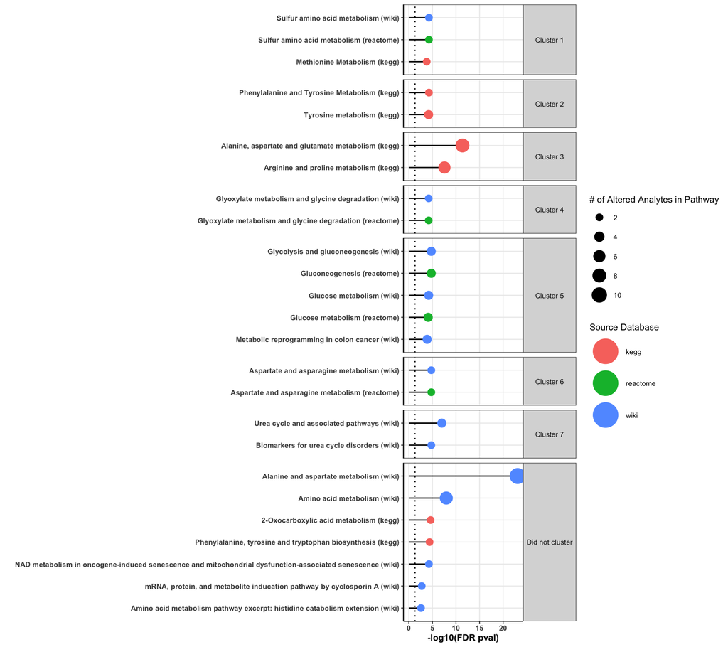

```r
pathwayResultsPlot(filtered.fisher.results, text_size = 8, perc_analyte_overlap = 0.2,
    min_pathway_tocluster = 2, perc_pathway_overlap = 0.2, interactive = FALSE)
```

### Perform Chemical Enrichment

After retrieving chemical classes of metabolites, the function chemicalClassEnrichment() function will perform overrepresentation analysis using a Fisher’s test and output classes that show enrichment in the user input list of metabolites relative to the backgroud metabolite population (all meteabolites in RaMP). The function performs enrichment analysis for Classyfire classes, sub-classess, and super-classes, and for LipidMaps categories, main classess, and sub classes.

```r
metabolites.of.interest = c('hmdb:HMDB0000056','hmdb:HMDB0000439','hmdb:HMDB0000479','hmdb:HMDB0000532',
                            'hmdb:HMDB0001015','hmdb:HMDB0001138','hmdb:HMDB0029159','hmdb:HMDB0029412',
                            'hmdb:HMDB0034365','hmdb:HMDB0035227','hmdb:HMDB0007973','hmdb:HMDB0008057',
                            'hmdb:HMDB0011211')
chemical.enrichment <- chemicalClassEnrichment(mets = metabolites.of.interest)
```

```
## [1] "Starting Chemical Class Enrichment"
## [1] "Starting Chemical Class Survey"
## [1] "...finished metabolite list query..."
## [1] "...finished DB population query..."
## [1] "...colating data..."
## [1] "...creating query efficiency summary..."
## [1] "Finished Chemical Class Survey"
## [1] "Finished Chemical Class Enrichment"
```

```r
# Enrichment was performed on the following chemical classes:
names(chemical.enrichment)
```

```
## [1] "ClassyFire_class"       "ClassyFire_sub_class"   "ClassyFire_super_class"
## [4] "LipidMaps_category"     "LipidMaps_main_class"   "LipidMaps_sub_class"
## [7] "result_type"
```

```r
# To retrieve results for the ClassyFire Class:
classy_fire_classes <- chemical.enrichment$ClassyFire_class
datatable(classy_fire_classes)
```

|  | category | class_name | met_hits | pop_hits | met_size | pop_size | p-value | adjP_BH |
| --- | --- | --- | --- | --- | --- | --- | --- | --- |
| 1 | ClassyFire_class | Carboxylic acids and derivatives | 10 | 4270 | 13 | 145833 | 1.20860263590028e-13 | 2.41720527180056e-13 |
| 2 | ClassyFire_class | Glycerophospholipids | 3 | 62689 | 13 | 145833 | 0.962918316412126 | 0.962918316412126 |

*Note*: To explicitly view the results of mapping input IDs to RaMP, users can run the chemicalClassSurvey() function as noted in above in the section “Retrieve Chemical Class from Input Metabolites”.